# Final_Group6

```python
import pandas as pd
import numpy as np
import matplotlib.pyplot as plt
from sklearn.feature_extraction.text import CountVectorizer
from sklearn.preprocessing import StandardScaler
from sklearn.preprocessing import LabelEncoder
import seaborn as sns
from sklearn.model_selection import train_test_split
from sklearn.linear_model import LogisticRegression
from sklearn.neighbors import KNeighborsClassifier
from sklearn.tree import DecisionTreeClassifier
from sklearn.metrics import precision_score
from sklearn.metrics import f1_score
from sklearn.metrics import recall_score
from sklearn.metrics import accuracy_score
import cv2
import tensorflow as tf
from tensorflow.keras.preprocessing.image import ImageDataGenerator
from tensorflow.keras import layers, models
from tensorflow.keras.callbacks import ModelCheckpoint
import os
import random
from tqdm import tqdm
```

```python
# read csv file
eye = pd.read_csv('full_df.csv')

# Displaying basic information
print("First Five Rows\n", eye.head(5))
print("\nShape (Rows, Columns)\n", eye.shape)
print("\nData Types\n", eye.dtypes)
```

```
First Five Rows
    ID  Patient Age Patient Sex       Fundus  \
0   0           69      Female  0_right.jpg
1   1           57        Male  1_right.jpg
2   2           42        Male  2_right.jpg
3   4           53        Male  4_right.jpg
4   5           50      Female  5_right.jpg

                      Diagnostic Keywords  N  D  G  C  A  H  M  O  \
0                           normal fundus  0  0  0  1  0  0  0  0
1                           normal fundus  1  0  0  0  0  0  0  0
2  moderate non proliferative retinopathy  0  1  0  0  0  0  0  1
3       mild nonproliferative retinopathy  0  1  0  0  0  0  0  1
4  moderate non proliferative retinopathy  0  1  0  0  0  0  0  0

                                            filepath labels  \
0  ../input/ocular-disease-recognition-odir5k/ODI...  ['N']
1  ../input/ocular-disease-recognition-odir5k/ODI...  ['N']
2  ../input/ocular-disease-recognition-odir5k/ODI...  ['D']
3  ../input/ocular-disease-recognition-odir5k/ODI...  ['D']
4  ../input/ocular-disease-recognition-odir5k/ODI...  ['D']

                     target     filename
0  [1, 0, 0, 0, 0, 0, 0, 0]  0_right.jpg
1  [1, 0, 0, 0, 0, 0, 0, 0]  1_right.jpg
2  [0, 1, 0, 0, 0, 0, 0, 0]  2_right.jpg
3  [0, 1, 0, 0, 0, 0, 0, 0]  4_right.jpg
4  [0, 1, 0, 0, 0, 0, 0, 0]  5_right.jpg

Shape (Rows, Columns)
 (3194, 17)

Data Types
 ID                      int64
Patient Age             int64
Patient Sex            object
Fundus                 object
Diagnostic Keywords    object
N                       int64
D                       int64
G                       int64
C                       int64
A                       int64
H                       int64
M                       int64
O                       int64
filepath               object
labels                 object
target                 object
filename               object
dtype: object
```

```python
# Store file as DataFrame
data= pd.DataFrame(eye)
# Data Stats.
data.describe()
```

|  | ID | Patient Age | N | D | G | C | A | H | M | O |
| --- | --- | --- | --- | --- | --- | --- | --- | --- | --- | --- |
| count | 3194.000000 | 3194.000000 | 3194.000000 | 3194.000000 | 3194.000000 | 3194.000000 | 3194.000000 | 3194.000000 | 3194.000000 | 3194.000000 |
| mean | 2269.190670 | 57.879775 | 0.329054 | 0.332185 | 0.062304 | 0.063244 | 0.049781 | 0.032248 | 0.048215 | 0.247652 |
| std | 1416.599237 | 11.789997 | 0.469943 | 0.471071 | 0.241745 | 0.243439 | 0.217526 | 0.176686 | 0.214255 | 0.431716 |
| min | 0.000000 | 1.000000 | 0.000000 | 0.000000 | 0.000000 | 0.000000 | 0.000000 | 0.000000 | 0.000000 | 0.000000 |
| 25% | 925.250000 | 51.000000 | 0.000000 | 0.000000 | 0.000000 | 0.000000 | 0.000000 | 0.000000 | 0.000000 | 0.000000 |
| 50% | 2417.500000 | 59.000000 | 0.000000 | 0.000000 | 0.000000 | 0.000000 | 0.000000 | 0.000000 | 0.000000 | 0.000000 |
| 75% | 3289.750000 | 66.000000 | 1.000000 | 1.000000 | 0.000000 | 0.000000 | 0.000000 | 0.000000 | 0.000000 | 0.000000 |
| max | 4784.000000 | 91.000000 | 1.000000 | 1.000000 | 1.000000 | 1.000000 | 1.000000 | 1.000000 | 1.000000 | 1.000000 |

1. The dataset contains 3194 rows and 17 columns.

.

1. Features:
   - ID: Integer
   - Patient Age: Integer
   - Patient Sex: Object (string)
   - Fundus: Object (string, references to image files)
   - Diagnostic Keywords: Object (string)
   - N, D, G, C, A, H, M, O: Integer (binary/indicator variables)
   - filepath: Object (string, file paths)
   - labels: Object (lists)
   - target: Object (lists)
   - filename: Object (string)

```python
# Data Column Names
print(list(data.columns))
```

```
['ID', 'Patient Age', 'Patient Sex', 'Fundus', 'Diagnostic Keywords', 'N', 'D', 'G', 'C', 'A', 'H', 'M', 'O', 'filepath', 'labels', 'target', 'filename']
```

overview of the columns:

- ID: Numerical ID of the entry.
- Patient Age: Age of the patient.
- Patient Sex: Gender of the patient.
- Fundus: The file name of the fundus image.
- Diagnostic Keywords: Keywords describing the diagnosis.
- N: Normal
- D: Diabetes
- G: Glaucoma
- C: Cataract
- A: Age related Macular Degeneration
- H: Hypertension
- M: Pathological Myopia
- O: Other diseases/abnormalities
- filepath: File path for the image df.
- labels: Labels in an array-like format.
- target: Target values in an array format.
- filename: Filename of the image.

### Missing Values Analysis

There are no missing values in the dataset.

```python
# Checking for missing values and duplicates
print("Missing Values:\n", data.isnull().sum())
print("Duplicate Entries: ", data.duplicated().sum())
```

```
Missing Values:
 ID                     0
Patient Age            0
Patient Sex            0
Fundus                 0
Diagnostic Keywords    0
N                      0
D                      0
G                      0
C                      0
A                      0
H                      0
M                      0
O                      0
filepath               0
labels                 0
target                 0
filename               0
dtype: int64
Duplicate Entries:  0
```

### Age Distribution of Patients:

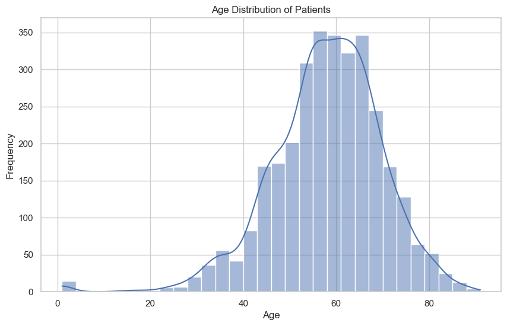

```python
import matplotlib.pyplot as plt
import seaborn as sns

# Setting the aesthetic style of the plots
sns.set(style="whitegrid")

# Plotting Age Distribution
plt.figure(figsize=(10, 6))
sns.histplot(data['Patient Age'], bins=30, kde=True)
plt.title('Age Distribution of Patients')
plt.xlabel('Age')
plt.ylabel('Frequency')
plt.show()
```

### Prevalence of Conditions:

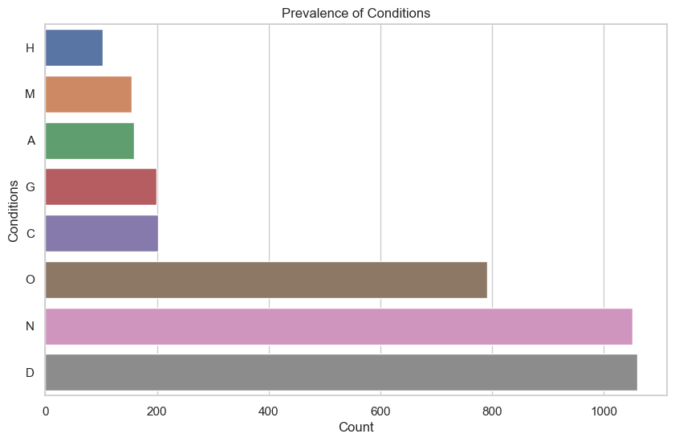

```python
# Plotting Condition Prevalence
conditions = ['N', 'D', 'G', 'C', 'A', 'H', 'M', 'O']
condition_counts = data[conditions].sum().sort_values()

plt.figure(figsize=(10, 6))
sns.barplot(x=condition_counts.values, y=condition_counts.index)
plt.title('Prevalence of Conditions')
plt.xlabel('Count')
plt.ylabel('Conditions')
plt.show()
```

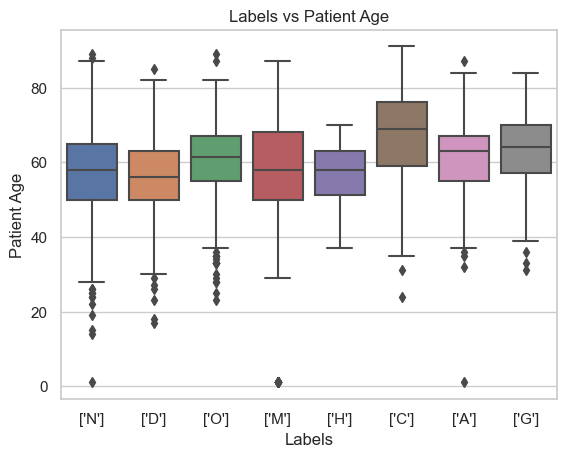

```python
# Plot Labels vs Patient Age
sns.boxplot(x='labels', y='Patient Age', data=data)
plt.title('Labels vs Patient Age')
plt.xlabel('Labels')
plt.ylabel('Patient Age')
plt.show()
```

```python
# Function to do Binary check
def has_condn(term,text):
    if term in text:
        return 1
    else:
        return 0
```

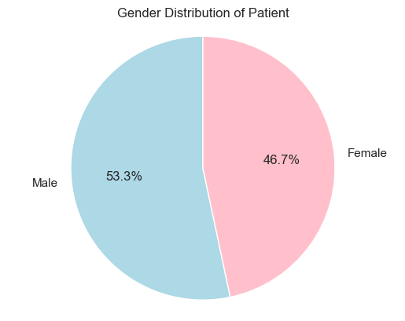

```python
# Plot Patient Gender Distribution
gender_counts = data['Patient Sex'].value_counts()
colors=['lightblue','pink']
plt.pie(gender_counts, labels=gender_counts.index, autopct='%1.1f%%', startangle=90,colors=colors)

plt.title('Gender Distribution of Patient')

plt.axis('equal')
plt.show()
```

```python
# # Grouping the df by age and counting the number of males and females in each group
# age_gender_distribution = data.groupby(['Patient Age', 'Patient Sex']).size().unstack(fill_value=0)

##plot
# colors = ['lightblue', 'pink']

# # Creating the stacked bar plot
# age_gender_distribution.plot(kind='bar', stacked=True, color=colors, figsize=(15, 7))
# plt.title('Distribution by Age and Stacked by Gender')
# plt.xlabel('Age')
# plt.ylabel('Count')
# plt.legend(title='Gender')
# plt.show()
```

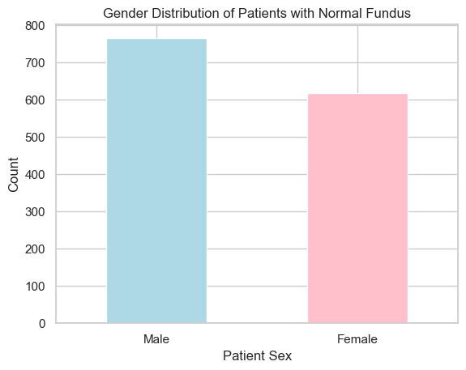

```python
# Filter data for Normal Condition
filtered_data = data[(data['Diagnostic Keywords'] == 'normal fundus')]

# Plot Patient Gender Distribution(count)
gender_counts = filtered_data['Patient Sex'].value_counts()
colors=['lightblue','pink']
gender_counts.plot(kind='bar', rot=0,color=colors)

plt.xlabel('Patient Sex')
plt.ylabel('Count')
plt.title('Gender Distribution of Patients with Normal Fundus')

plt.show()
```

[figure not shown]

```python
# Normal cases for age>60
senior_citizens = data[(data['Diagnostic Keywords'] == 'normal fundus') &(data['Patient Age'] >= 60)]

# Plot Patient Gender Distribution for Age>60
colors=['lightblue','pink']
gender_counts.plot(kind='bar', rot=0,color=colors)

plt.xlabel('Patient Sex')
plt.ylabel('Count')
plt.title('Gender Distribution of Senior(>60) citizens with Normal Fundus ')
plt.show()
```

# Data Transformation

### Fixing File path

```python
# File Path Variable
base_dir = '/Users/shivamthakur/Desktop/Python/Data Mining(Kaggle)/code/ODIR-5K/preprocessed_images/'

# Set filepath
data['filepath']= base_dir + data['filename']
data.head(5)

#data.to_csv('Data.csv', index=False)
```

|  | ID | Patient Age | Patient Sex | Fundus | Diagnostic Keywords | N | D | G | C | A | H | M | O | filepath | labels | target | filename |
| --- | --- | --- | --- | --- | --- | --- | --- | --- | --- | --- | --- | --- | --- | --- | --- | --- | --- |
| 0 | 0 | 69 | Female | 0_right.jpg | normal fundus | 0 | 0 | 0 | 1 | 0 | 0 | 0 | 0 | /Users/shivamthakur/Desktop/Python/Data Mining... | ['N'] | [1, 0, 0, 0, 0, 0, 0, 0] | 0_right.jpg |
| 1 | 1 | 57 | Male | 1_right.jpg | normal fundus | 1 | 0 | 0 | 0 | 0 | 0 | 0 | 0 | /Users/shivamthakur/Desktop/Python/Data Mining... | ['N'] | [1, 0, 0, 0, 0, 0, 0, 0] | 1_right.jpg |
| 2 | 2 | 42 | Male | 2_right.jpg | moderate non proliferative retinopathy | 0 | 1 | 0 | 0 | 0 | 0 | 0 | 1 | /Users/shivamthakur/Desktop/Python/Data Mining... | ['D'] | [0, 1, 0, 0, 0, 0, 0, 0] | 2_right.jpg |
| 3 | 4 | 53 | Male | 4_right.jpg | mild nonproliferative retinopathy | 0 | 1 | 0 | 0 | 0 | 0 | 0 | 1 | /Users/shivamthakur/Desktop/Python/Data Mining... | ['D'] | [0, 1, 0, 0, 0, 0, 0, 0] | 4_right.jpg |
| 4 | 5 | 50 | Female | 5_right.jpg | moderate non proliferative retinopathy | 0 | 1 | 0 | 0 | 0 | 0 | 0 | 0 | /Users/shivamthakur/Desktop/Python/Data Mining... | ['D'] | [0, 1, 0, 0, 0, 0, 0, 0] | 5_right.jpg |

### Encoding Patient Sex

```python
gender_mapping = {'Male': 0, 'Female': 1}
data['Patient Sex'] = data['Patient Sex'].map(gender_mapping)
```

```python
data
```

|  | ID | Patient Age | Patient Sex | Fundus | Diagnostic Keywords | N | D | G | C | A | H | M | O | filepath | labels | target | filename |
| --- | --- | --- | --- | --- | --- | --- | --- | --- | --- | --- | --- | --- | --- | --- | --- | --- | --- |
| 0 | 0 | 69 | 1 | 0_right.jpg | normal fundus | 0 | 0 | 0 | 1 | 0 | 0 | 0 | 0 | /Users/shivamthakur/Desktop/Python/Data Mining... | ['N'] | [1, 0, 0, 0, 0, 0, 0, 0] | 0_right.jpg |
| 1 | 1 | 57 | 0 | 1_right.jpg | normal fundus | 1 | 0 | 0 | 0 | 0 | 0 | 0 | 0 | /Users/shivamthakur/Desktop/Python/Data Mining... | ['N'] | [1, 0, 0, 0, 0, 0, 0, 0] | 1_right.jpg |
| 2 | 2 | 42 | 0 | 2_right.jpg | moderate non proliferative retinopathy | 0 | 1 | 0 | 0 | 0 | 0 | 0 | 1 | /Users/shivamthakur/Desktop/Python/Data Mining... | ['D'] | [0, 1, 0, 0, 0, 0, 0, 0] | 2_right.jpg |
| 3 | 4 | 53 | 0 | 4_right.jpg | mild nonproliferative retinopathy | 0 | 1 | 0 | 0 | 0 | 0 | 0 | 1 | /Users/shivamthakur/Desktop/Python/Data Mining... | ['D'] | [0, 1, 0, 0, 0, 0, 0, 0] | 4_right.jpg |
| 4 | 5 | 50 | 1 | 5_right.jpg | moderate non proliferative retinopathy | 0 | 1 | 0 | 0 | 0 | 0 | 0 | 0 | /Users/shivamthakur/Desktop/Python/Data Mining... | ['D'] | [0, 1, 0, 0, 0, 0, 0, 0] | 5_right.jpg |
| ... | ... | ... | ... | ... | ... | ... | ... | ... | ... | ... | ... | ... | ... | ... | ... | ... | ... |
| 3189 | 4686 | 63 | 0 | 4686_right.jpg | proliferative diabetic retinopathy | 0 | 1 | 0 | 0 | 0 | 0 | 0 | 0 | /Users/shivamthakur/Desktop/Python/Data Mining... | ['D'] | [0, 1, 0, 0, 0, 0, 0, 0] | 4686_right.jpg |
| 3190 | 4688 | 42 | 0 | 4688_right.jpg | moderate non proliferative retinopathy | 0 | 1 | 0 | 0 | 0 | 0 | 0 | 0 | /Users/shivamthakur/Desktop/Python/Data Mining... | ['D'] | [0, 1, 0, 0, 0, 0, 0, 0] | 4688_right.jpg |
| 3191 | 4689 | 54 | 0 | 4689_right.jpg | normal fundus | 0 | 1 | 0 | 0 | 0 | 0 | 0 | 0 | /Users/shivamthakur/Desktop/Python/Data Mining... | ['N'] | [1, 0, 0, 0, 0, 0, 0, 0] | 4689_right.jpg |
| 3192 | 4690 | 57 | 0 | 4690_right.jpg | mild nonproliferative retinopathy | 0 | 1 | 0 | 0 | 0 | 0 | 0 | 0 | /Users/shivamthakur/Desktop/Python/Data Mining... | ['D'] | [0, 1, 0, 0, 0, 0, 0, 0] | 4690_right.jpg |
| 3193 | 4784 | 58 | 0 | 4784_right.jpg | hypertensive retinopathy，age-related macular d... | 0 | 0 | 0 | 0 | 1 | 1 | 0 | 0 | /Users/shivamthakur/Desktop/Python/Data Mining... | ['H'] | [0, 0, 0, 0, 0, 1, 0, 0] | 4784_right.jpg |

3194 rows × 17 columns

### Encoding Diagnostic Keywwords

##### Split Diagnostic Keywords by comma seperation

```python
# Replace "non proliferative retinopathy" with "nonproliferativeretinopathy"
data['Diagnostic Keywords'] = data['Diagnostic Keywords'].str.replace('proliferative retinopathy', 'proliferativeretinopathy', regex=False)

# Splitting the 'Diagnostic Keywords' column by comma and expanding into separate rows
# Each keyword will have its own row with other columns duplicated
data_separated = data.drop('Diagnostic Keywords', axis=1).join(
    data['Diagnostic Keywords'].str.split('，', expand=True).stack().reset_index(level=1, drop=True).rename('Diagnostic Keyword')
)

# Removing leading and trailing spaces from the 'Diagnostic Keyword' column
data_separated['Diagnostic Keyword'] = data_separated['Diagnostic Keyword'].str.strip()

# Rearranging the columns to place the new 'Diagnostic Keyword' column after the 'Fundus' column
columns = list(data_separated.columns)
columns.remove('Diagnostic Keyword')
new_column_order = columns[:4] + ['Diagnostic Keyword'] + columns[4:]
data_reordered = data_separated[new_column_order]

data_reordered.head(36)
```

|  | ID | Patient Age | Patient Sex | Fundus | Diagnostic Keyword | N | D | G | C | A | H | M | O | filepath | labels | target | filename |
| --- | --- | --- | --- | --- | --- | --- | --- | --- | --- | --- | --- | --- | --- | --- | --- | --- | --- |
| 0 | 0 | 69 | 1 | 0_right.jpg | normal fundus | 0 | 0 | 0 | 1 | 0 | 0 | 0 | 0 | /Users/shivamthakur/Desktop/Python/Data Mining... | ['N'] | [1, 0, 0, 0, 0, 0, 0, 0] | 0_right.jpg |
| 1 | 1 | 57 | 0 | 1_right.jpg | normal fundus | 1 | 0 | 0 | 0 | 0 | 0 | 0 | 0 | /Users/shivamthakur/Desktop/Python/Data Mining... | ['N'] | [1, 0, 0, 0, 0, 0, 0, 0] | 1_right.jpg |
| 2 | 2 | 42 | 0 | 2_right.jpg | moderate non proliferativeretinopathy | 0 | 1 | 0 | 0 | 0 | 0 | 0 | 1 | /Users/shivamthakur/Desktop/Python/Data Mining... | ['D'] | [0, 1, 0, 0, 0, 0, 0, 0] | 2_right.jpg |
| 3 | 4 | 53 | 0 | 4_right.jpg | mild nonproliferativeretinopathy | 0 | 1 | 0 | 0 | 0 | 0 | 0 | 1 | /Users/shivamthakur/Desktop/Python/Data Mining... | ['D'] | [0, 1, 0, 0, 0, 0, 0, 0] | 4_right.jpg |
| 4 | 5 | 50 | 1 | 5_right.jpg | moderate non proliferativeretinopathy | 0 | 1 | 0 | 0 | 0 | 0 | 0 | 0 | /Users/shivamthakur/Desktop/Python/Data Mining... | ['D'] | [0, 1, 0, 0, 0, 0, 0, 0] | 5_right.jpg |
| 5 | 6 | 60 | 0 | 6_right.jpg | moderate non proliferativeretinopathy | 0 | 1 | 0 | 0 | 0 | 0 | 0 | 1 | /Users/shivamthakur/Desktop/Python/Data Mining... | ['D'] | [0, 1, 0, 0, 0, 0, 0, 0] | 6_right.jpg |
| 5 | 6 | 60 | 0 | 6_right.jpg | epiretinal membrane | 0 | 1 | 0 | 0 | 0 | 0 | 0 | 1 | /Users/shivamthakur/Desktop/Python/Data Mining... | ['D'] | [0, 1, 0, 0, 0, 0, 0, 0] | 6_right.jpg |
| 6 | 7 | 60 | 1 | 7_right.jpg | mild nonproliferativeretinopathy | 0 | 1 | 0 | 0 | 0 | 0 | 0 | 1 | /Users/shivamthakur/Desktop/Python/Data Mining... | ['D'] | [0, 1, 0, 0, 0, 0, 0, 0] | 7_right.jpg |
| 7 | 8 | 59 | 0 | 8_right.jpg | normal fundus | 1 | 0 | 0 | 0 | 0 | 0 | 0 | 0 | /Users/shivamthakur/Desktop/Python/Data Mining... | ['N'] | [1, 0, 0, 0, 0, 0, 0, 0] | 8_right.jpg |
| 8 | 9 | 54 | 0 | 9_right.jpg | vitreous degeneration | 0 | 0 | 0 | 0 | 0 | 0 | 0 | 1 | /Users/shivamthakur/Desktop/Python/Data Mining... | ['O'] | [0, 0, 0, 0, 0, 0, 0, 1] | 9_right.jpg |
| 9 | 10 | 70 | 0 | 10_right.jpg | normal fundus | 0 | 0 | 0 | 0 | 0 | 0 | 0 | 1 | /Users/shivamthakur/Desktop/Python/Data Mining... | ['N'] | [1, 0, 0, 0, 0, 0, 0, 0] | 10_right.jpg |
| 10 | 11 | 60 | 1 | 11_right.jpg | moderate non proliferativeretinopathy | 0 | 1 | 0 | 0 | 0 | 1 | 0 | 0 | /Users/shivamthakur/Desktop/Python/Data Mining... | ['D'] | [0, 1, 0, 0, 0, 0, 0, 0] | 11_right.jpg |
| 10 | 11 | 60 | 1 | 11_right.jpg | hypertensive retinopathy | 0 | 1 | 0 | 0 | 0 | 1 | 0 | 0 | /Users/shivamthakur/Desktop/Python/Data Mining... | ['D'] | [0, 1, 0, 0, 0, 0, 0, 0] | 11_right.jpg |
| 11 | 13 | 60 | 1 | 13_right.jpg | pathological myopia | 0 | 0 | 0 | 0 | 0 | 0 | 1 | 0 | /Users/shivamthakur/Desktop/Python/Data Mining... | ['M'] | [0, 0, 0, 0, 0, 0, 1, 0] | 13_right.jpg |
| 12 | 14 | 55 | 0 | 14_right.jpg | macular epiretinal membrane | 0 | 0 | 0 | 0 | 0 | 0 | 0 | 1 | /Users/shivamthakur/Desktop/Python/Data Mining... | ['O'] | [0, 0, 0, 0, 0, 0, 0, 1] | 14_right.jpg |
| 13 | 15 | 50 | 0 | 15_right.jpg | myelinated nerve fibers | 0 | 0 | 0 | 0 | 0 | 0 | 0 | 1 | /Users/shivamthakur/Desktop/Python/Data Mining... | ['O'] | [0, 0, 0, 0, 0, 0, 0, 1] | 15_right.jpg |
| 14 | 16 | 54 | 1 | 16_right.jpg | pathological myopia | 0 | 0 | 0 | 0 | 0 | 0 | 1 | 0 | /Users/shivamthakur/Desktop/Python/Data Mining... | ['M'] | [0, 0, 0, 0, 0, 0, 1, 0] | 16_right.jpg |
| 15 | 17 | 57 | 0 | 17_right.jpg | drusen | 0 | 0 | 0 | 0 | 0 | 0 | 0 | 1 | /Users/shivamthakur/Desktop/Python/Data Mining... | ['O'] | [0, 0, 0, 0, 0, 0, 0, 1] | 17_right.jpg |
| 16 | 18 | 58 | 0 | 18_right.jpg | pathological myopia | 0 | 0 | 0 | 0 | 0 | 0 | 1 | 0 | /Users/shivamthakur/Desktop/Python/Data Mining... | ['M'] | [0, 0, 0, 0, 0, 0, 1, 0] | 18_right.jpg |
| 17 | 19 | 45 | 0 | 19_right.jpg | mild nonproliferativeretinopathy | 0 | 1 | 0 | 0 | 0 | 0 | 0 | 0 | /Users/shivamthakur/Desktop/Python/Data Mining... | ['D'] | [0, 1, 0, 0, 0, 0, 0, 0] | 19_right.jpg |
| 18 | 21 | 76 | 1 | 21_right.jpg | epiretinal membrane | 0 | 0 | 0 | 0 | 0 | 0 | 0 | 1 | /Users/shivamthakur/Desktop/Python/Data Mining... | ['O'] | [0, 0, 0, 0, 0, 0, 0, 1] | 21_right.jpg |
| 19 | 23 | 47 | 0 | 23_right.jpg | hypertensive retinopathy | 0 | 0 | 0 | 0 | 0 | 1 | 0 | 0 | /Users/shivamthakur/Desktop/Python/Data Mining... | ['H'] | [0, 0, 0, 0, 0, 1, 0, 0] | 23_right.jpg |
| 20 | 24 | 75 | 1 | 24_right.jpg | cataract | 0 | 0 | 0 | 1 | 0 | 0 | 0 | 0 | /Users/shivamthakur/Desktop/Python/Data Mining... | ['C'] | [0, 0, 0, 1, 0, 0, 0, 0] | 24_right.jpg |
| 21 | 26 | 63 | 1 | 26_right.jpg | moderate non proliferativeretinopathy | 0 | 1 | 0 | 0 | 0 | 0 | 0 | 1 | /Users/shivamthakur/Desktop/Python/Data Mining... | ['D'] | [0, 1, 0, 0, 0, 0, 0, 0] | 26_right.jpg |
| 21 | 26 | 63 | 1 | 26_right.jpg | abnormal pigment | 0 | 1 | 0 | 0 | 0 | 0 | 0 | 1 | /Users/shivamthakur/Desktop/Python/Data Mining... | ['D'] | [0, 1, 0, 0, 0, 0, 0, 0] | 26_right.jpg |
| 22 | 27 | 33 | 0 | 27_right.jpg | macular epiretinal membrane | 0 | 1 | 0 | 0 | 0 | 0 | 0 | 1 | /Users/shivamthakur/Desktop/Python/Data Mining... | ['O'] | [0, 0, 0, 0, 0, 0, 0, 1] | 27_right.jpg |
| 22 | 27 | 33 | 0 | 27_right.jpg | moderate non proliferativeretinopathy | 0 | 1 | 0 | 0 | 0 | 0 | 0 | 1 | /Users/shivamthakur/Desktop/Python/Data Mining... | ['O'] | [0, 0, 0, 0, 0, 0, 0, 1] | 27_right.jpg |
| 23 | 28 | 63 | 1 | 28_right.jpg | hypertensive retinopathy | 0 | 0 | 0 | 0 | 0 | 1 | 0 | 0 | /Users/shivamthakur/Desktop/Python/Data Mining... | ['H'] | [0, 0, 0, 0, 0, 1, 0, 0] | 28_right.jpg |
| 24 | 29 | 59 | 0 | 29_right.jpg | normal fundus | 0 | 0 | 0 | 0 | 0 | 0 | 0 | 1 | /Users/shivamthakur/Desktop/Python/Data Mining... | ['N'] | [1, 0, 0, 0, 0, 0, 0, 0] | 29_right.jpg |
| 25 | 31 | 62 | 0 | 31_right.jpg | normal fundus | 0 | 0 | 0 | 0 | 0 | 0 | 0 | 1 | /Users/shivamthakur/Desktop/Python/Data Mining... | ['N'] | [1, 0, 0, 0, 0, 0, 0, 0] | 31_right.jpg |
| 26 | 32 | 64 | 1 | 32_right.jpg | hypertensive retinopathy | 0 | 0 | 0 | 0 | 0 | 1 | 0 | 0 | /Users/shivamthakur/Desktop/Python/Data Mining... | ['H'] | [0, 0, 0, 0, 0, 1, 0, 0] | 32_right.jpg |
| 27 | 33 | 60 | 1 | 33_right.jpg | macular epiretinal membrane | 0 | 0 | 0 | 0 | 0 | 0 | 0 | 1 | /Users/shivamthakur/Desktop/Python/Data Mining... | ['O'] | [0, 0, 0, 0, 0, 0, 0, 1] | 33_right.jpg |
| 28 | 34 | 61 | 0 | 34_right.jpg | drusen | 0 | 0 | 0 | 0 | 0 | 0 | 0 | 1 | /Users/shivamthakur/Desktop/Python/Data Mining... | ['O'] | [0, 0, 0, 0, 0, 0, 0, 1] | 34_right.jpg |
| 29 | 35 | 68 | 1 | 35_right.jpg | normal fundus | 0 | 0 | 0 | 0 | 0 | 0 | 1 | 0 | /Users/shivamthakur/Desktop/Python/Data Mining... | ['N'] | [1, 0, 0, 0, 0, 0, 0, 0] | 35_right.jpg |
| 30 | 37 | 41 | 0 | 37_right.jpg | normal fundus | 0 | 1 | 0 | 0 | 0 | 0 | 0 | 1 | /Users/shivamthakur/Desktop/Python/Data Mining... | ['N'] | [1, 0, 0, 0, 0, 0, 0, 0] | 37_right.jpg |
| 31 | 38 | 75 | 0 | 38_right.jpg | normal fundus | 0 | 0 | 0 | 0 | 0 | 0 | 0 | 1 | /Users/shivamthakur/Desktop/Python/Data Mining... | ['N'] | [1, 0, 0, 0, 0, 0, 0, 0] | 38_right.jpg |

##### Map Keywords in Diagnostic Keywords

```python
def categorize_row(keyword):
    keyword = keyword.lower()
    if 'abnormal' in keyword:
        return 'O'                ###outlier case matching with normal
    elif 'normal' in keyword:
        return 'N'
    elif 'proliferativeretinopathy' in keyword:
        return 'D'
    elif 'glaucoma' in keyword:
        return 'G'
    elif 'cataract' in keyword:
        return 'C'
    elif 'macular degeneration' in keyword:
        return 'A'
    elif 'hypertensive' in keyword:
        return 'H'
    elif 'myopia' in keyword:
        return 'M'
    else:
        return 'O'

# Apply the categorization function to each row
data_reordered = data_reordered.copy()

# Apply the categorization function to each row
data_reordered['Categorized Keyword'] = data_reordered['Diagnostic Keyword'].apply(categorize_row)
data_reordered
```

|  | ID | Patient Age | Patient Sex | Fundus | Diagnostic Keyword | N | D | G | C | A | H | M | O | filepath | labels | target | filename | Categorized Keyword |
| --- | --- | --- | --- | --- | --- | --- | --- | --- | --- | --- | --- | --- | --- | --- | --- | --- | --- | --- |
| 0 | 0 | 69 | 1 | 0_right.jpg | normal fundus | 0 | 0 | 0 | 1 | 0 | 0 | 0 | 0 | /Users/shivamthakur/Desktop/Python/Data Mining... | ['N'] | [1, 0, 0, 0, 0, 0, 0, 0] | 0_right.jpg | N |
| 1 | 1 | 57 | 0 | 1_right.jpg | normal fundus | 1 | 0 | 0 | 0 | 0 | 0 | 0 | 0 | /Users/shivamthakur/Desktop/Python/Data Mining... | ['N'] | [1, 0, 0, 0, 0, 0, 0, 0] | 1_right.jpg | N |
| 2 | 2 | 42 | 0 | 2_right.jpg | moderate non proliferativeretinopathy | 0 | 1 | 0 | 0 | 0 | 0 | 0 | 1 | /Users/shivamthakur/Desktop/Python/Data Mining... | ['D'] | [0, 1, 0, 0, 0, 0, 0, 0] | 2_right.jpg | D |
| 3 | 4 | 53 | 0 | 4_right.jpg | mild nonproliferativeretinopathy | 0 | 1 | 0 | 0 | 0 | 0 | 0 | 1 | /Users/shivamthakur/Desktop/Python/Data Mining... | ['D'] | [0, 1, 0, 0, 0, 0, 0, 0] | 4_right.jpg | D |
| 4 | 5 | 50 | 1 | 5_right.jpg | moderate non proliferativeretinopathy | 0 | 1 | 0 | 0 | 0 | 0 | 0 | 0 | /Users/shivamthakur/Desktop/Python/Data Mining... | ['D'] | [0, 1, 0, 0, 0, 0, 0, 0] | 5_right.jpg | D |
| ... | ... | ... | ... | ... | ... | ... | ... | ... | ... | ... | ... | ... | ... | ... | ... | ... | ... | ... |
| 3190 | 4688 | 42 | 0 | 4688_right.jpg | moderate non proliferativeretinopathy | 0 | 1 | 0 | 0 | 0 | 0 | 0 | 0 | /Users/shivamthakur/Desktop/Python/Data Mining... | ['D'] | [0, 1, 0, 0, 0, 0, 0, 0] | 4688_right.jpg | D |
| 3191 | 4689 | 54 | 0 | 4689_right.jpg | normal fundus | 0 | 1 | 0 | 0 | 0 | 0 | 0 | 0 | /Users/shivamthakur/Desktop/Python/Data Mining... | ['N'] | [1, 0, 0, 0, 0, 0, 0, 0] | 4689_right.jpg | N |
| 3192 | 4690 | 57 | 0 | 4690_right.jpg | mild nonproliferativeretinopathy | 0 | 1 | 0 | 0 | 0 | 0 | 0 | 0 | /Users/shivamthakur/Desktop/Python/Data Mining... | ['D'] | [0, 1, 0, 0, 0, 0, 0, 0] | 4690_right.jpg | D |
| 3193 | 4784 | 58 | 0 | 4784_right.jpg | hypertensive retinopathy | 0 | 0 | 0 | 0 | 1 | 1 | 0 | 0 | /Users/shivamthakur/Desktop/Python/Data Mining... | ['H'] | [0, 0, 0, 0, 0, 1, 0, 0] | 4784_right.jpg | H |
| 3193 | 4784 | 58 | 0 | 4784_right.jpg | age-related macular degeneration | 0 | 0 | 0 | 0 | 1 | 1 | 0 | 0 | /Users/shivamthakur/Desktop/Python/Data Mining... | ['H'] | [0, 0, 0, 0, 0, 1, 0, 0] | 4784_right.jpg | A |

3480 rows × 18 columns

#### Encoding Diagnostic Keyword column

```python
# enumerating the unique values of the text data in both the columns
unique_values = data_reordered['Diagnostic Keyword'].unique()
value_to_number = {value: number for number, value in enumerate(unique_values, start=1)}
data_reordered['Diagnostic Keyword'] = data_reordered['Diagnostic Keyword'].replace(value_to_number)
```

```python
data_reordered.head(5)
```

|  | ID | Patient Age | Patient Sex | Fundus | Diagnostic Keyword | N | D | G | C | A | H | M | O | filepath | labels | target | filename | Categorized Keyword |
| --- | --- | --- | --- | --- | --- | --- | --- | --- | --- | --- | --- | --- | --- | --- | --- | --- | --- | --- |
| 0 | 0 | 69 | 1 | 0_right.jpg | 1 | 0 | 0 | 0 | 1 | 0 | 0 | 0 | 0 | /Users/shivamthakur/Desktop/Python/Data Mining... | ['N'] | [1, 0, 0, 0, 0, 0, 0, 0] | 0_right.jpg | N |
| 1 | 1 | 57 | 0 | 1_right.jpg | 1 | 1 | 0 | 0 | 0 | 0 | 0 | 0 | 0 | /Users/shivamthakur/Desktop/Python/Data Mining... | ['N'] | [1, 0, 0, 0, 0, 0, 0, 0] | 1_right.jpg | N |
| 2 | 2 | 42 | 0 | 2_right.jpg | 2 | 0 | 1 | 0 | 0 | 0 | 0 | 0 | 1 | /Users/shivamthakur/Desktop/Python/Data Mining... | ['D'] | [0, 1, 0, 0, 0, 0, 0, 0] | 2_right.jpg | D |
| 3 | 4 | 53 | 0 | 4_right.jpg | 3 | 0 | 1 | 0 | 0 | 0 | 0 | 0 | 1 | /Users/shivamthakur/Desktop/Python/Data Mining... | ['D'] | [0, 1, 0, 0, 0, 0, 0, 0] | 4_right.jpg | D |
| 4 | 5 | 50 | 1 | 5_right.jpg | 2 | 0 | 1 | 0 | 0 | 0 | 0 | 0 | 0 | /Users/shivamthakur/Desktop/Python/Data Mining... | ['D'] | [0, 1, 0, 0, 0, 0, 0, 0] | 5_right.jpg | D |

#### number of Unique values

```python
data_reordered['Diagnostic Keyword'].nunique()
```

```
48
```

##### Selecting rows where labels=Categorized Keywords(Mapped from Diagnostic Keywords)

```python
# Convert 'labels' from string representation of list to actual list
import ast

data_reordered['labels'] = data_reordered['labels'].apply(ast.literal_eval)

# Filter the data where 'Categorized Keyword' is in the 'labels' list
filtered_data = data_reordered[data_reordered.apply(lambda row: row['Categorized Keyword'] in row['labels'], axis=1)]

# Display the first few rows of the filtered data
filtered_data
```

|  | ID | Patient Age | Patient Sex | Fundus | Diagnostic Keyword | N | D | G | C | A | H | M | O | filepath | labels | target | filename | Categorized Keyword |
| --- | --- | --- | --- | --- | --- | --- | --- | --- | --- | --- | --- | --- | --- | --- | --- | --- | --- | --- |
| 0 | 0 | 69 | 1 | 0_right.jpg | 1 | 0 | 0 | 0 | 1 | 0 | 0 | 0 | 0 | /Users/shivamthakur/Desktop/Python/Data Mining... | [N] | [1, 0, 0, 0, 0, 0, 0, 0] | 0_right.jpg | N |
| 1 | 1 | 57 | 0 | 1_right.jpg | 1 | 1 | 0 | 0 | 0 | 0 | 0 | 0 | 0 | /Users/shivamthakur/Desktop/Python/Data Mining... | [N] | [1, 0, 0, 0, 0, 0, 0, 0] | 1_right.jpg | N |
| 2 | 2 | 42 | 0 | 2_right.jpg | 2 | 0 | 1 | 0 | 0 | 0 | 0 | 0 | 1 | /Users/shivamthakur/Desktop/Python/Data Mining... | [D] | [0, 1, 0, 0, 0, 0, 0, 0] | 2_right.jpg | D |
| 3 | 4 | 53 | 0 | 4_right.jpg | 3 | 0 | 1 | 0 | 0 | 0 | 0 | 0 | 1 | /Users/shivamthakur/Desktop/Python/Data Mining... | [D] | [0, 1, 0, 0, 0, 0, 0, 0] | 4_right.jpg | D |
| 4 | 5 | 50 | 1 | 5_right.jpg | 2 | 0 | 1 | 0 | 0 | 0 | 0 | 0 | 0 | /Users/shivamthakur/Desktop/Python/Data Mining... | [D] | [0, 1, 0, 0, 0, 0, 0, 0] | 5_right.jpg | D |
| ... | ... | ... | ... | ... | ... | ... | ... | ... | ... | ... | ... | ... | ... | ... | ... | ... | ... | ... |
| 3188 | 4683 | 58 | 0 | 4683_right.jpg | 3 | 0 | 1 | 0 | 0 | 0 | 0 | 0 | 0 | /Users/shivamthakur/Desktop/Python/Data Mining... | [D] | [0, 1, 0, 0, 0, 0, 0, 0] | 4683_right.jpg | D |
| 3190 | 4688 | 42 | 0 | 4688_right.jpg | 2 | 0 | 1 | 0 | 0 | 0 | 0 | 0 | 0 | /Users/shivamthakur/Desktop/Python/Data Mining... | [D] | [0, 1, 0, 0, 0, 0, 0, 0] | 4688_right.jpg | D |
| 3191 | 4689 | 54 | 0 | 4689_right.jpg | 1 | 0 | 1 | 0 | 0 | 0 | 0 | 0 | 0 | /Users/shivamthakur/Desktop/Python/Data Mining... | [N] | [1, 0, 0, 0, 0, 0, 0, 0] | 4689_right.jpg | N |
| 3192 | 4690 | 57 | 0 | 4690_right.jpg | 3 | 0 | 1 | 0 | 0 | 0 | 0 | 0 | 0 | /Users/shivamthakur/Desktop/Python/Data Mining... | [D] | [0, 1, 0, 0, 0, 0, 0, 0] | 4690_right.jpg | D |
| 3193 | 4784 | 58 | 0 | 4784_right.jpg | 6 | 0 | 0 | 0 | 0 | 1 | 1 | 0 | 0 | /Users/shivamthakur/Desktop/Python/Data Mining... | [H] | [0, 0, 0, 0, 0, 1, 0, 0] | 4784_right.jpg | H |

3204 rows × 18 columns

#### Encode Categorized Keywords

```python
df=filtered_data
```

```python
# Encoding Categorized Keyword LabelEncoder
label_encoder = LabelEncoder()
df['Categorized Keyword'] = label_encoder.fit_transform(df['Categorized Keyword'])

label_mapping = dict(zip(label_encoder.classes_, label_encoder.transform(label_encoder.classes_)))
```

```python
df=df.drop('labels',axis=1)
```

```python
df
```

|  | ID | Patient Age | Patient Sex | Fundus | Diagnostic Keyword | N | D | G | C | A | H | M | O | filepath | target | filename | Categorized Keyword |
| --- | --- | --- | --- | --- | --- | --- | --- | --- | --- | --- | --- | --- | --- | --- | --- | --- | --- |
| 0 | 0 | 69 | 1 | 0_right.jpg | 1 | 0 | 0 | 0 | 1 | 0 | 0 | 0 | 0 | /Users/shivamthakur/Desktop/Python/Data Mining... | [1, 0, 0, 0, 0, 0, 0, 0] | 0_right.jpg | 6 |
| 1 | 1 | 57 | 0 | 1_right.jpg | 1 | 1 | 0 | 0 | 0 | 0 | 0 | 0 | 0 | /Users/shivamthakur/Desktop/Python/Data Mining... | [1, 0, 0, 0, 0, 0, 0, 0] | 1_right.jpg | 6 |
| 2 | 2 | 42 | 0 | 2_right.jpg | 2 | 0 | 1 | 0 | 0 | 0 | 0 | 0 | 1 | /Users/shivamthakur/Desktop/Python/Data Mining... | [0, 1, 0, 0, 0, 0, 0, 0] | 2_right.jpg | 2 |
| 3 | 4 | 53 | 0 | 4_right.jpg | 3 | 0 | 1 | 0 | 0 | 0 | 0 | 0 | 1 | /Users/shivamthakur/Desktop/Python/Data Mining... | [0, 1, 0, 0, 0, 0, 0, 0] | 4_right.jpg | 2 |
| 4 | 5 | 50 | 1 | 5_right.jpg | 2 | 0 | 1 | 0 | 0 | 0 | 0 | 0 | 0 | /Users/shivamthakur/Desktop/Python/Data Mining... | [0, 1, 0, 0, 0, 0, 0, 0] | 5_right.jpg | 2 |
| ... | ... | ... | ... | ... | ... | ... | ... | ... | ... | ... | ... | ... | ... | ... | ... | ... | ... |
| 3188 | 4683 | 58 | 0 | 4683_right.jpg | 3 | 0 | 1 | 0 | 0 | 0 | 0 | 0 | 0 | /Users/shivamthakur/Desktop/Python/Data Mining... | [0, 1, 0, 0, 0, 0, 0, 0] | 4683_right.jpg | 2 |
| 3190 | 4688 | 42 | 0 | 4688_right.jpg | 2 | 0 | 1 | 0 | 0 | 0 | 0 | 0 | 0 | /Users/shivamthakur/Desktop/Python/Data Mining... | [0, 1, 0, 0, 0, 0, 0, 0] | 4688_right.jpg | 2 |
| 3191 | 4689 | 54 | 0 | 4689_right.jpg | 1 | 0 | 1 | 0 | 0 | 0 | 0 | 0 | 0 | /Users/shivamthakur/Desktop/Python/Data Mining... | [1, 0, 0, 0, 0, 0, 0, 0] | 4689_right.jpg | 6 |
| 3192 | 4690 | 57 | 0 | 4690_right.jpg | 3 | 0 | 1 | 0 | 0 | 0 | 0 | 0 | 0 | /Users/shivamthakur/Desktop/Python/Data Mining... | [0, 1, 0, 0, 0, 0, 0, 0] | 4690_right.jpg | 2 |
| 3193 | 4784 | 58 | 0 | 4784_right.jpg | 6 | 0 | 0 | 0 | 0 | 1 | 1 | 0 | 0 | /Users/shivamthakur/Desktop/Python/Data Mining... | [0, 0, 0, 0, 0, 1, 0, 0] | 4784_right.jpg | 4 |

3204 rows × 17 columns

# Modeling

```python
df = df.drop(columns=['Fundus','filepath','filename','target'])
```

```python
df.head(5)
```

|  | ID | Patient Age | Patient Sex | Diagnostic Keyword | N | D | G | C | A | H | M | O | Categorized Keyword |
| --- | --- | --- | --- | --- | --- | --- | --- | --- | --- | --- | --- | --- | --- |
| 0 | 0 | 69 | 1 | 1 | 0 | 0 | 0 | 1 | 0 | 0 | 0 | 0 | 6 |
| 1 | 1 | 57 | 0 | 1 | 1 | 0 | 0 | 0 | 0 | 0 | 0 | 0 | 6 |
| 2 | 2 | 42 | 0 | 2 | 0 | 1 | 0 | 0 | 0 | 0 | 0 | 1 | 2 |
| 3 | 4 | 53 | 0 | 3 | 0 | 1 | 0 | 0 | 0 | 0 | 0 | 1 | 2 |
| 4 | 5 | 50 | 1 | 2 | 0 | 1 | 0 | 0 | 0 | 0 | 0 | 0 | 2 |

#### Initializing X and y

```python
y = df['Categorized Keyword']
X = df.drop(columns=['ID', 'Categorized Keyword'])
```

```python
print(X.head(5))
y.head(5)
```

```
   Patient Age  Patient Sex  Diagnostic Keyword  N  D  G  C  A  H  M  O
0           69            1                   1  0  0  0  1  0  0  0  0
1           57            0                   1  1  0  0  0  0  0  0  0
2           42            0                   2  0  1  0  0  0  0  0  1
3           53            0                   3  0  1  0  0  0  0  0  1
4           50            1                   2  0  1  0  0  0  0  0  0
```

```
0    6
1    6
2    2
3    2
4    2
Name: Categorized Keyword, dtype: int64
```

#### Correlation Matrix

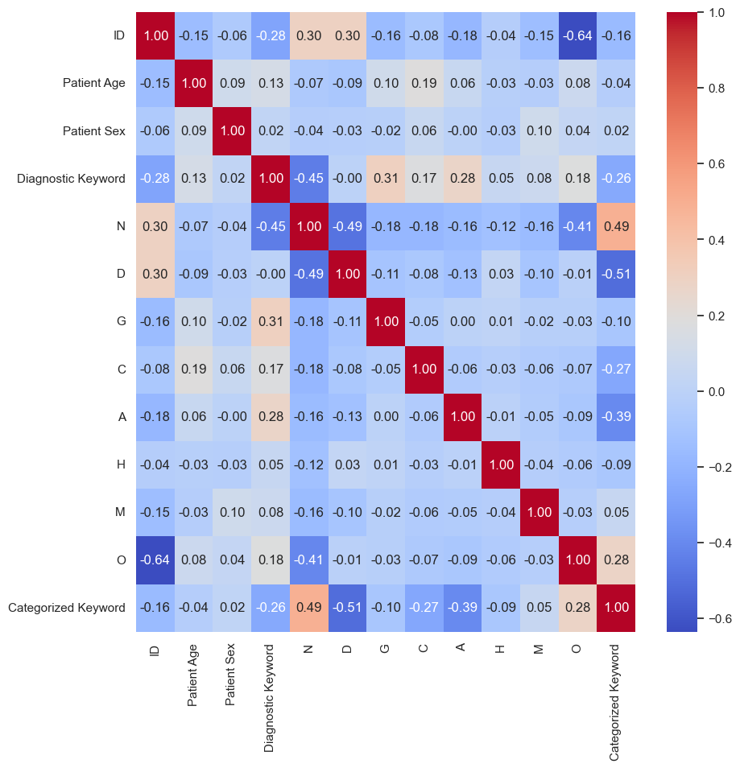

```python
plt.figure(figsize=(10, 10))
correlation_matrix = df.corr()
sns.heatmap(correlation_matrix, annot=True, cmap='coolwarm', fmt=".2f")
plt.show()
```

#### Splitting the data

```python
# spliting the data
X_train, X_test, y_train, y_test = train_test_split(X, y, test_size=0.2, random_state=42)
```

#### Logistic Regression

```python
LR_model1 = LogisticRegression()
LR_model1.fit(X_train, y_train)

y_pred = LR_model1.predict(X_train)
precision = precision_score(y_train, y_pred, average='weighted')
f1 = f1_score(y_train, y_pred, average='weighted')
recall = recall_score(y_train, y_pred, average='weighted')
acc = accuracy_score(y_train, y_pred)

print('RESULTS FOR THE LOGISTIC REGRESSION - TRAINING DATA')
print('-----------------------------------------------------')
print(f'Logistic Regression Model - training dataset, the precision is: {precision}')
print(f'Logistic Regression Model - training dataset, the f1-score is: {f1}')
print(f'Logistic Regression Model - training dataset, the recall is: {recall}')
print(f'Logistic Regression Model - training dataset, the accuracy is: {acc}\n')

y_pred = LR_model1.predict(X_test)

precision = precision_score(y_test, y_pred, average='weighted')
f1 = f1_score(y_test, y_pred, average='weighted')
recall = recall_score(y_test, y_pred, average='weighted')
acc = accuracy_score(y_test, y_pred)

print('RESULTS FOR THE LOGISTIC REGRESSION - TESTING DATA')
print('-----------------------------------------------------')
print(f'Logistic Regression Model - testing dataset, the precision is: {precision}')
print(f'Logistic Regression Model - testing dataset, the f1-score is: {f1}')
print(f'Logistic Regression Model - testing dataset, the recall is: {recall}')
print(f'Logistic Regression Model - testing dataset, the accuracy is: {acc}\n')
```

```
RESULTS FOR THE LOGISTIC REGRESSION - TRAINING DATA
-----------------------------------------------------
Logistic Regression Model - training dataset, the precision is: 0.9320099341526322
Logistic Regression Model - training dataset, the f1-score is: 0.9262939661181018
Logistic Regression Model - training dataset, the recall is: 0.9274287943815841
Logistic Regression Model - training dataset, the accuracy is: 0.9274287943815841

RESULTS FOR THE LOGISTIC REGRESSION - TESTING DATA
-----------------------------------------------------
Logistic Regression Model - testing dataset, the precision is: 0.9325817919080399
Logistic Regression Model - testing dataset, the f1-score is: 0.9247995909989513
Logistic Regression Model - testing dataset, the recall is: 0.9266770670826833
Logistic Regression Model - testing dataset, the accuracy is: 0.9266770670826833
```

#### KNN

```python
KNN_model2 = KNeighborsClassifier()
KNN_model2.fit(X_train, y_train)

y_pred = KNN_model2.predict(X_train)
precision = precision_score(y_train, y_pred, average='weighted')
f1 = f1_score(y_train, y_pred, average='weighted')
recall = recall_score(y_train, y_pred, average='weighted')
acc = accuracy_score(y_train, y_pred)

print('RESULTS FOR THE KNN - TRAINING DATA')
print('-----------------------------------------------------')
print(f'KNN Model - training dataset, the precision is: {precision}')
print(f'KNN Model - training dataset, the f1-score is: {f1}')
print(f'KNN Model - training dataset, the recall is: {recall}')
print(f'KNN Model - training dataset, the accuracy is: {acc}\n')

y_pred = KNN_model2.predict(X_test)
precision = precision_score(y_test, y_pred, average='weighted')
f1 = f1_score(y_test, y_pred, average='weighted')
recall = recall_score(y_test, y_pred, average='weighted')
acc = accuracy_score(y_test, y_pred)

print('RESULTS FOR THE KNN - TESTING DATA')
print('-----------------------------------------------------')
print(f'KNN Model - testing dataset, the precision is: {precision}')
print(f'KNN Model - testing dataset, the f1-score is: {f1}')
print(f'KNN Model - testing dataset, the recall is: {recall}')
print(f'KNN Model - testing dataset, the accuracy is: {acc}\n')
```

```
RESULTS FOR THE KNN - TRAINING DATA
-----------------------------------------------------
KNN Model - training dataset, the precision is: 0.97655416831335
KNN Model - training dataset, the f1-score is: 0.9760849894011043
KNN Model - training dataset, the recall is: 0.9761997658993368
KNN Model - training dataset, the accuracy is: 0.9761997658993368

RESULTS FOR THE KNN - TESTING DATA
-----------------------------------------------------
KNN Model - testing dataset, the precision is: 0.9590919282109529
KNN Model - testing dataset, the f1-score is: 0.957632804290308
KNN Model - testing dataset, the recall is: 0.9578783151326054
KNN Model - testing dataset, the accuracy is: 0.9578783151326054
```

```python
len(X_test)
```

```
641
```

#### checking the predicted label and the actual label

```python
# checking the predicted label and the actual label
# 1st value in the test data

y_pred = LR_model1.predict(X_test)
actual_label = y_test.iloc[1]

predicted_original_label = next(key for key, value in label_mapping.items() if value == y_pred[1])
actual_original_label = next(key for key, value in label_mapping.items() if value == actual_label)

# Output the original labels
print(f"Predicted Label: {predicted_original_label}")
print(f"Actual Label: {actual_original_label}")
```

```
Predicted Label: D
Actual Label: D
```

```python
# checking the predicted label and the actual label
# 3rd value in the test data

y_pred = LR_model1.predict(X_test)
actual_label = y_test.iloc[3]

predicted_original_label = next(key for key, value in label_mapping.items() if value == y_pred[3])
actual_original_label = next(key for key, value in label_mapping.items() if value == actual_label)

# Output the original labels
print(f"Predicted Label: {predicted_original_label}")
print(f"Actual Label: {actual_original_label}")
```

```
Predicted Label: N
Actual Label: N
```

```python
# checking the predicted label and the actual label
# 5th value in the test data

y_pred = LR_model1.predict(X_test)
actual_label = y_test.iloc[15]

predicted_original_label = next(key for key, value in label_mapping.items() if value == y_pred[15])
actual_original_label = next(key for key, value in label_mapping.items() if value == actual_label)

# Output the original labels
print(f"Predicted Label: {predicted_original_label}")
print(f"Actual Label: {actual_original_label}")
```

```
Predicted Label: D
Actual Label: D
```

### Modeling Data for CNN

```python
img_df = pd.DataFrame(data)
img_df.head(5)
```

|  | ID | Patient Age | Patient Sex | Fundus | Diagnostic Keywords | N | D | G | C | A | H | M | O | filepath | labels | target | filename |
| --- | --- | --- | --- | --- | --- | --- | --- | --- | --- | --- | --- | --- | --- | --- | --- | --- | --- |
| 0 | 0 | 69 | 1 | 0_right.jpg | normal fundus | 0 | 0 | 0 | 1 | 0 | 0 | 0 | 0 | /Users/shivamthakur/Desktop/Python/Data Mining... | ['N'] | [1, 0, 0, 0, 0, 0, 0, 0] | 0_right.jpg |
| 1 | 1 | 57 | 0 | 1_right.jpg | normal fundus | 1 | 0 | 0 | 0 | 0 | 0 | 0 | 0 | /Users/shivamthakur/Desktop/Python/Data Mining... | ['N'] | [1, 0, 0, 0, 0, 0, 0, 0] | 1_right.jpg |
| 2 | 2 | 42 | 0 | 2_right.jpg | moderate non proliferativeretinopathy | 0 | 1 | 0 | 0 | 0 | 0 | 0 | 1 | /Users/shivamthakur/Desktop/Python/Data Mining... | ['D'] | [0, 1, 0, 0, 0, 0, 0, 0] | 2_right.jpg |
| 3 | 4 | 53 | 0 | 4_right.jpg | mild nonproliferativeretinopathy | 0 | 1 | 0 | 0 | 0 | 0 | 0 | 1 | /Users/shivamthakur/Desktop/Python/Data Mining... | ['D'] | [0, 1, 0, 0, 0, 0, 0, 0] | 4_right.jpg |
| 4 | 5 | 50 | 1 | 5_right.jpg | moderate non proliferativeretinopathy | 0 | 1 | 0 | 0 | 0 | 0 | 0 | 0 | /Users/shivamthakur/Desktop/Python/Data Mining... | ['D'] | [0, 1, 0, 0, 0, 0, 0, 0] | 5_right.jpg |

```python
img_df = img_df[['filepath','labels']]
img_df.head(5)
```

|  | filepath | labels |
| --- | --- | --- |
| 0 | /Users/shivamthakur/Desktop/Python/Data Mining... | ['N'] |
| 1 | /Users/shivamthakur/Desktop/Python/Data Mining... | ['N'] |
| 2 | /Users/shivamthakur/Desktop/Python/Data Mining... | ['D'] |
| 3 | /Users/shivamthakur/Desktop/Python/Data Mining... | ['D'] |
| 4 | /Users/shivamthakur/Desktop/Python/Data Mining... | ['D'] |

```python
def load_and_preprocess_image(filepath):
    img = cv2.imread(filepath)
    img = cv2.resize(img, (224, 224))
    #img = img / 255.0  # Normalize pixel values to be between 0 and 1
    return img

img_df['images'] = img_df['filepath'].apply(load_and_preprocess_image)

img_df.head(5)
```

|  | filepath | labels | images |
| --- | --- | --- | --- |
| 0 | /Users/shivamthakur/Desktop/Python/Data Mining... | ['N'] | [[[0, 0, 0], [0, 0, 0], [0, 0, 0], [0, 0, 0], ... |
| 1 | /Users/shivamthakur/Desktop/Python/Data Mining... | ['N'] | [[[0, 0, 0], [0, 0, 0], [0, 0, 0], [0, 0, 0], ... |
| 2 | /Users/shivamthakur/Desktop/Python/Data Mining... | ['D'] | [[[0, 0, 0], [0, 0, 0], [0, 0, 0], [0, 0, 0], ... |
| 3 | /Users/shivamthakur/Desktop/Python/Data Mining... | ['D'] | [[[0, 0, 0], [0, 0, 0], [0, 0, 0], [0, 0, 0], ... |
| 4 | /Users/shivamthakur/Desktop/Python/Data Mining... | ['D'] | [[[0, 0, 0], [0, 0, 0], [0, 0, 0], [0, 0, 0], ... |

#### Images of the first 5 rows

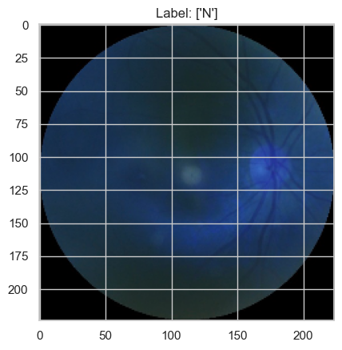

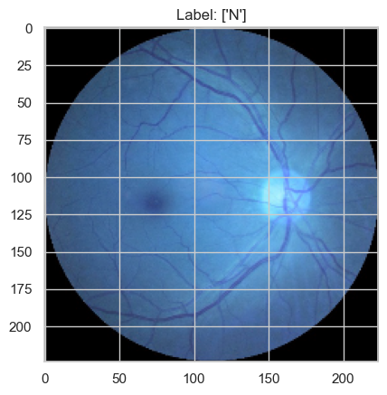

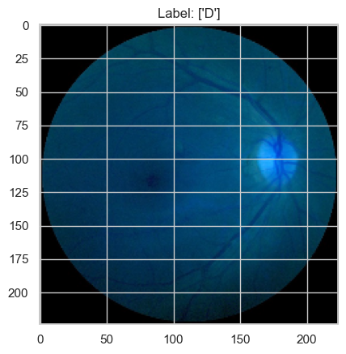

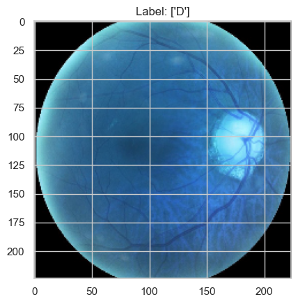

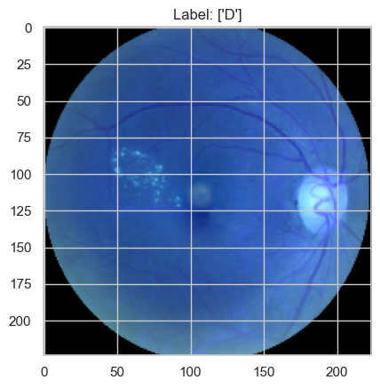

```python
# Display the first 5 images
for i in range(5):
    plt.imshow(img_df['images'][i])
    plt.title(f"Label: {img_df['labels'][i]}")
    plt.show()
```

```python
def read_and_resize(image_path, target_size=(224, 224)):
    image = cv2.imread(image_path)
    image = cv2.resize(image, target_size)
    return image

img_df['images'] = img_df['filepath'].apply(read_and_resize)
```

#### Label Encode Images

```python
label_encoder = LabelEncoder()
img_df['encoded_labels'] = label_encoder.fit_transform(img_df['labels'])
```

```python
train_df, test_df = train_test_split(img_df, test_size=0.2, random_state=42)
```

#### Image Data Generator

```python
datagen = ImageDataGenerator(rescale=1./255, validation_split=0.2)
```

```python
# Flow from dataframe with target size, class mode, and batch size
train_generator = datagen.flow_from_dataframe(
    dataframe=train_df,
    x_col="filepath",
    y_col="encoded_labels",
    subset="training",
    batch_size=32,
    seed=42,
    shuffle=True,
    class_mode="raw",
    target_size=(224, 224)  # adjust target size as needed
)
valid_generator = datagen.flow_from_dataframe(
    dataframe=train_df,
    x_col="filepath",
    y_col="encoded_labels",
    subset="validation",
    batch_size=32,
    seed=42,
    shuffle=True,
    class_mode="raw",
    target_size=(224, 224)  # adjust target size as needed
)
```

```
Found 2044 validated image filenames.
Found 511 validated image filenames.
```

#### CNN1

```python
# CNN Model
model = models.Sequential()
model.add(layers.Conv2D(32, (3, 3), activation='relu', input_shape=(224, 224, 3)))
model.add(layers.MaxPooling2D((2, 2)))
model.add(layers.Conv2D(64, (3, 3), activation='relu'))
model.add(layers.MaxPooling2D((2, 2)))
model.add(layers.Conv2D(128, (3, 3), activation='relu'))
model.add(layers.MaxPooling2D((2, 2)))
model.add(layers.Flatten())
model.add(layers.Dense(128, activation='relu'))
model.add(layers.Dense(len(label_encoder.classes_), activation='softmax'))
```

```python
# Compile the model
model.compile(optimizer='adam',
              loss='sparse_categorical_crossentropy',
              metrics=['accuracy'])

# Save the best model during training
model_checkpoint = ModelCheckpoint('best_model.h5', save_best_only=True, save_weights_only=False, monitor='val_loss',
                                   mode='min', verbose=1)

# Train the model
history = model.fit(train_generator,
                    epochs=10,  # adjust the number of epochs
                    validation_data=valid_generator,
                    callbacks=[model_checkpoint])
```

```
Epoch 1: val_loss improved from inf to 1.56081, saving model to best_model.h5
```

```
Epoch 2: val_loss did not improve from 1.56081
Epoch 3: val_loss improved from 1.56081 to 1.51694, saving model to best_model.h5
Epoch 4: val_loss did not improve from 1.51694
Epoch 5: val_loss improved from 1.51694 to 1.48877, saving model to best_model.h5
Epoch 6: val_loss improved from 1.48877 to 1.45621, saving model to best_model.h5
Epoch 7: val_loss improved from 1.45621 to 1.43004, saving model to best_model.h5
Epoch 8: val_loss did not improve from 1.43004
Epoch 9: val_loss did not improve from 1.43004
Epoch 10: val_loss did not improve from 1.43004
```

```python
# eval test data

test_datagen = ImageDataGenerator(rescale=1./255)

test_generator = test_datagen.flow_from_dataframe(
    dataframe=test_df,
    x_col="filepath",
    y_col="encoded_labels",
    batch_size=32,
    seed=42,
    shuffle=False,
    class_mode="raw",
    target_size=(224, 224)  # adjust target size as needed
)

# Load the best model weights
model.load_weights('best_model.h5')

# Evaluate the model on the test set
test_loss, test_accuracy = model.evaluate(test_generator)
print(f"Test Accuracy: {test_accuracy * 100:.2f}%")
```

```
Found 639 validated image filenames.
Test Accuracy: 44.76%
```

```
True Label: ['D']
Predicted Label: ['N']
```

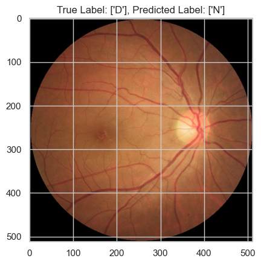

```python
sample_data = test_df.sample(1)
sample_img_path = sample_data['filepath'].values[0]
sample_label = sample_data['encoded_labels'].values[0]

# Read and preprocess the image
sample_image = read_and_resize(sample_img_path)
sample_image = np.expand_dims(sample_image, axis=0) / 255.0

# Make prediction
prediction = model.predict(sample_image)
predicted_label = label_encoder.inverse_transform([np.argmax(prediction)])

print(f"True Label: {label_encoder.inverse_transform([sample_label])[0]}")
print(f"Predicted Label: {predicted_label[0]}")

# Display the image
import matplotlib.pyplot as plt
plt.imshow(cv2.cvtColor(cv2.imread(sample_img_path), cv2.COLOR_BGR2RGB))
plt.title(f"True Label: {label_encoder.inverse_transform([sample_label])[0]}, Predicted Label: {predicted_label[0]}")
plt.show()
```

### Modeling Data for CNN

```python
import os
import cv2
import numpy as np
import pandas as pd
import random
from tqdm import tqdm

# Set image size
image_size = 224

# Function to load the dataset
def dataset_generator(csv_file):
    # Load the CSV file
    data = csv_file

    # Initialize the dataset list
    dataset = []

    # Iterate through each row in the dataframe
    for index, row in tqdm(data.iterrows(), total=data.shape[0]):
        img_path = row['filepath']
        label = row['Categorized Keyword']

        # Try to read the image and resize it
        try:
            image = cv2.imread(img_path, cv2.IMREAD_COLOR)
            image = cv2.resize(image, (image_size, image_size))
        except Exception as e:
            print(f"Error loading image {img_path}: {e}")
            continue

        # Append the image and its label to the dataset
        dataset.append([np.array(image), np.array(label)])

    # Shuffle the dataset
    random.shuffle(dataset)

    return dataset

# Path to the CSV file
csv_file = filtered_data  # Replace with your CSV file path

# Generate the dataset
dataset = dataset_generator(csv_file)
```

#### CNN2

[figure not shown]

```python
plt.figure(figsize=(12,7))
for i in range(10):
    sample = random.choice(range(len(dataset)))
    image = dataset[sample][0]
    category = dataset[sample][1]

    if category== 0:
        label = "Normal"
    elif category == 1 :
        label = "Cataract"
    elif category == 2:
        label = "Diabetes"
    elif category == 3:
        label = "Glaucoma"
    elif category == 4:
        label = "Hypertension"
    elif category == 5:
        label = "Myopia"
    elif category == 6:
        label = "Age Issues"
    else:
        label = "Other"

    plt.subplot(2,6,i+1)
    plt.imshow(image)
    plt.xlabel(label)
plt.tight_layout()
```

```python
#Divide the dataset into 2 predictors and target...
#here predictors would be the image and target would be the label

train_x = np.array([i[0] for i in dataset]).reshape(-1,image_size,image_size,3);
train_y = np.array([i[1] for i in dataset])

from sklearn.model_selection import train_test_split
from tensorflow.keras.utils import to_categorical
#splitting the dataset
x_train , x_test , y_train, y_test = train_test_split(train_x,train_y, test_size=0.2)

y_train_cat = to_categorical(y_train,num_classes=8)

y_test_cat = to_categorical(y_test,num_classes = 8)
```

#### Model

```python
from tensorflow.keras.applications.vgg19 import VGG19
import tensorflow as tf
vgg = VGG19(weights="imagenet",include_top = False,input_shape=(image_size,image_size,3))

for layer in vgg.layers:
    layer.trainable = False

from tensorflow.keras import Sequential
from tensorflow.keras.layers import Flatten,Dense
model = Sequential()
model.add(vgg)
model.add(Flatten())
model.add(Dense(256,activation = "relu"))
model.add(tf.keras.layers.BatchNormalization())
model.add(Dense(256,activation = "relu"))
model.add(tf.keras.layers.BatchNormalization())
model.add(Dense(8,activation="softmax"))

model.summary()
```

```
Model: "sequential_1"
_________________________________________________________________
 Layer (type)                Output Shape              Param #
=================================================================
 vgg19 (Functional)          (None, 7, 7, 512)         20024384

 flatten_1 (Flatten)         (None, 25088)             0

 dense_2 (Dense)             (None, 256)               6422784

 batch_normalization (Batch  (None, 256)               1024
 Normalization)

 dense_3 (Dense)             (None, 256)               65792

 batch_normalization_1 (Bat  (None, 256)               1024
 chNormalization)

 dense_4 (Dense)             (None, 8)                 2056

=================================================================
Total params: 26517064 (101.15 MB)
Trainable params: 6491656 (24.76 MB)
Non-trainable params: 20025408 (76.39 MB)
_________________________________________________________________
```

```python
model.compile(optimizer="adam",loss="categorical_crossentropy",metrics=["accuracy"])
#u might have to apply train_generator and test_generator
history = model.fit(x_train,y_train_cat,batch_size=32,epochs=15)
print(history)
```

```
<keras.src.callbacks.History object at 0x2a375bf90>
```

```python
loss,accuracy = model.evaluate(x_test,y_test_cat)
print("Accuracy:",accuracy)
```

```
Accuracy: 0.4602183997631073
```

```python
from sklearn.metrics import confusion_matrix,classification_report,accuracy_score
# y_pred = np.array((model.predict(x_test) > 0.5).astype("int32"))

y_pred = []
for i in model.predict(x_test):
    y_pred.append(np.argmax(np.array(i)).astype("int32"))

print(y_pred)
```

```
[2, 2, 1, 6, 1, 0, 6, 1, 2, 6, 2, 6, 6, 6, 1, 2, 6, 2, 2, 6, 6, 7, 1, 2, 6, 6, 6, 7, 4, 2, 2, 2, 1, 6, 3, 2, 5, 6, 2, 6, 1, 6, 7, 6, 2, 6, 0, 6, 6, 6, 6, 7, 6, 0, 5, 7, 2, 7, 2, 6, 6, 7, 6, 6, 2, 5, 2, 2, 0, 2, 6, 2, 6, 6, 0, 6, 2, 0, 6, 5, 6, 2, 7, 0, 2, 7, 7, 0, 0, 2, 2, 6, 7, 7, 6, 6, 0, 6, 6, 6,…
```

```python
print(accuracy_score(y_test,y_pred))
```

```
0.46021840873634945
```

[figure not shown]

```python
plt.figure(figsize=(12,7))
for i in range(20):
    sample = random.choice(range(len(x_test)))
    image = x_test[sample]
    category = y_test[sample]
    pred_category = y_pred[sample]

    if category== 0:
        label = "Normal"
    elif category == 1 :
        label = "Cataract"
    elif category == 2:
        label = "Diabetes"
    elif category == 3:
        label = "Glaucoma"
    elif category == 4:
        label = "Hypertension"
    elif category == 5:
        label = "Myopia"
    elif category == 6:
        label = "Age Issues"
    else:
        label = "Other"

    if pred_category== 0:
        pred_label = "Normal"
    elif pred_category == 1 :
        pred_label = "Cataract"
    elif pred_category == 2:
        pred_label = "Diabetes"
    elif pred_category == 3:
        pred_label = "Glaucoma"
    elif pred_category == 4:
        pred_label = "Hypertension"
    elif pred_category == 5:
        pred_label = "Myopia"
    elif pred_category == 6:
        pred_label = "Age Issues"
    else:
        pred_label = "Other"

    plt.subplot(4,5,i+1)
    plt.imshow(image)
    plt.xlabel("Actual:{}\nPrediction:{}".format(label,pred_label))
plt.tight_layout()
```

```python
model.save("CNN2_trained_model.h5")
```

```python
from tensorflow.keras.models import load_model
model = load_model('my_trained_model.h5')
```

```python
new_image_path = '/Users/shivamthakur/Desktop/Python/Data Mining(Kaggle)/code/ODIR-5K/preprocessed_images/1020_left.jpg'
new_image = cv2.imread(new_image_path)
new_image = cv2.resize(new_image, (224, 224))
new_image = new_image / 255.0

# Perform inference
predictions = model.predict(np.expand_dims(new_image, axis=0))

# Get the class with the highest probability
predicted_class = np.argmax(predictions)

# Now 'predicted_class' contains the predicted class label for the new image
print(f"Actual: {label}")
print(f"Predicted class: {pred_label}")
```

```
Actual: Diabetes
Predicted class: Diabetes
```

#### CNN3

```python
import tensorflow as tf
from tensorflow.keras.models import Sequential
from tensorflow.keras.layers import Conv2D, MaxPooling2D, Flatten, Dense, Dropout
from tensorflow.keras.preprocessing.image import ImageDataGenerator
from sklearn.model_selection import train_test_split
from tensorflow.keras.utils import to_categorical

# Assuming X and Y are your images and labels respectively
X_train, X_test, y_train, y_test = train_test_split(train_x,train_y, test_size=0.15, random_state=42)

y_train_cat = to_categorical(y_train,num_classes=8)

y_test_cat = to_categorical(y_test,num_classes = 8)

# Preprocessing and data augmentation
train_datagen = ImageDataGenerator(
    rescale=1./255,
    rotation_range=20,
    width_shift_range=0.2,
    height_shift_range=0.2,
    horizontal_flip=True)

test_datagen = ImageDataGenerator(rescale=1./255)

# Flow training images in batches
train_generator = train_datagen.flow(
    X_train,
    y_train_cat,
    batch_size=32)

# Flow validation images in batches
test_generator = test_datagen.flow(
    X_test,
    y_test_cat,
    batch_size=32)

# Build the CNN model
model = Sequential([
    Conv2D(32, (3, 3), activation='relu', input_shape=(224, 224, 3)),
    MaxPooling2D(2, 2),
    Conv2D(64, (3, 3), activation='relu'),
    MaxPooling2D(2, 2),
    Conv2D(128, (3, 3), activation='relu'),
    MaxPooling2D(2, 2),
    Flatten(),
    Dense(512, activation='relu'),
    Dropout(0.5),
    Dense(8, activation='softmax')  # Assuming 8 classes
])

# Compile the model
model.compile(loss='categorical_crossentropy',
              optimizer='adam',
              metrics=['accuracy'])

# Train the model
history = model.fit(
    train_generator,
    steps_per_epoch=len(X_train) // 32,  # Number of batches per epoch
    epochs=25,
    validation_data=test_generator,
    validation_steps=len(X_test) // 32)

# Evaluate the model
model.evaluate(test_generator)

# Predict on new data
predictions = model.predict(test_generator)
```

#### CNN4

Here are some strategies to improve the model's performance:

1.Architecture Changes:

Add more convolutional layers or increase the number of filters in existing layers to capture more complex features. Include Batch Normalization layers to stabilize learning and potentially improve convergence speed. Experiment with different activation functions like LeakyReLU or ELU in place of ReLU.

1. Regularization:

Increase the dropout rate or add dropout layers to mitigate overfitting if the training accuracy is significantly higher than the validation accuracy. Try L1 or L2 regularization in the dense layers.

1. Optimizer and Learning Rate:

Experiment with different optimizers like SGD, RMSprop, or Adam, and adjust the learning rate and momentum. Implement learning rate schedulers or ReduceLROnPlateau to adjust the learning rate during training.

1. Data Augmentation:

Intensify data augmentation to create a more robust model that can generalize better.

1. Class Weights or Sample Weights:

If the dataset is imbalanced, use class weights or sample weights to give more importance to underrepresented classes.

1. Hyperparameter Tuning:

Use techniques like Grid Search or Random Search to find the optimal set of hyperparameters.

1. Advanced Techniques:

Try advanced architectures like ResNet, Inception, or Xception that are known to perform well on image data. Explore transfer learning by using pre-trained models and fine-tuning them for your specific dataset.

1. Evaluation Metrics:

Besides accuracy, consider using additional metrics relevant to the dataset's context, such as precision, recall, F1-score, or the AUC-ROC curve, especially if dealing with imbalanced classes.

1. Error Analysis:

Perform an error analysis to understand where the model is making mistakes and if there's a pattern or bias in these errors.

1. Data Quality:

Check the quality of the data. Ensure there are no mislabeled images, the images are well preprocessed, and the dataset does not contain any corrupt files.

1. Network Initialization:

Experiment with different weight initialization methods to start the training from a better point in the parameter space.

1. Early Stopping:

Use early stopping to halt the training when the validation loss stops improving, preventing overfitting.

1. Training for More Epochs:

Sometimes, the model may require more epochs to learn effectively, especially if learning rates are low.

```python
from tensorflow.keras.models import Sequential
from tensorflow.keras.layers import Conv2D, MaxPooling2D, Flatten, Dense, Dropout, BatchNormalization, LeakyReLU

# Initialize the model
model = Sequential()

# First block of conv -> batch norm -> pooling
model.add(Conv2D(32, (3, 3), padding='same', input_shape=(224, 224, 3)))
model.add(BatchNormalization())
model.add(LeakyReLU(alpha=0.1))
model.add(MaxPooling2D(pool_size=(2, 2)))
model.add(Dropout(0.25))

# Second block
model.add(Conv2D(64, (3, 3), padding='same'))
model.add(BatchNormalization())
model.add(LeakyReLU(alpha=0.1))
model.add(MaxPooling2D(pool_size=(2, 2)))
model.add(Dropout(0.25))

# Third block
model.add(Conv2D(128, (3, 3), padding='same'))
model.add(BatchNormalization())
model.add(LeakyReLU(alpha=0.1))
model.add(MaxPooling2D(pool_size=(2, 2)))
model.add(Dropout(0.25))

# Fourth block
model.add(Conv2D(256, (3, 3), padding='same'))
model.add(BatchNormalization())
model.add(LeakyReLU(alpha=0.1))
model.add(MaxPooling2D(pool_size=(2, 2)))
model.add(Dropout(0.25))

# Flattening followed by Dense -> BatchNorm -> Dropout
model.add(Flatten())
model.add(Dense(512))
model.add(BatchNormalization())
model.add(LeakyReLU(alpha=0.1))
model.add(Dropout(0.5))

# Output layer
model.add(Dense(8, activation='softmax'))  # Assuming 8 classes

# Compile the model
model.compile(optimizer='adam',
              loss='categorical_crossentropy',
              metrics=['accuracy'])

# Model summary
model.summary()
```

```
Model: "sequential_3"
_________________________________________________________________
 Layer (type)                Output Shape              Param #
=================================================================
 conv2d_6 (Conv2D)           (None, 224, 224, 32)      896

 batch_normalization_2 (Bat  (None, 224, 224, 32)      128
 chNormalization)

 leaky_re_lu (LeakyReLU)     (None, 224, 224, 32)      0

 max_pooling2d_6 (MaxPoolin  (None, 112, 112, 32)      0
 g2D)

 dropout_1 (Dropout)         (None, 112, 112, 32)      0

 conv2d_7 (Conv2D)           (None, 112, 112, 64)      18496

 batch_normalization_3 (Bat  (None, 112, 112, 64)      256
 chNormalization)

 leaky_re_lu_1 (LeakyReLU)   (None, 112, 112, 64)      0

 max_pooling2d_7 (MaxPoolin  (None, 56, 56, 64)        0
 g2D)

 dropout_2 (Dropout)         (None, 56, 56, 64)        0

 conv2d_8 (Conv2D)           (None, 56, 56, 128)       73856

 batch_normalization_4 (Bat  (None, 56, 56, 128)       512
 chNormalization)

 leaky_re_lu_2 (LeakyReLU)   (None, 56, 56, 128)       0

 max_pooling2d_8 (MaxPoolin  (None, 28, 28, 128)       0
 g2D)

 dropout_3 (Dropout)         (None, 28, 28, 128)       0

```

[output cut: 15 more lines]

```

 batch_normalization_6 (Bat  (None, 512)               2048
 chNormalization)

 leaky_re_lu_4 (LeakyReLU)   (None, 512)               0

 dropout_5 (Dropout)         (None, 512)               0

 dense_8 (Dense)             (None, 8)                 4104

=================================================================
Total params: 26087112 (99.51 MB)
Trainable params: 26085128 (99.51 MB)
Non-trainable params: 1984 (7.75 KB)
_________________________________________________________________
```

```python
from tensorflow.keras.preprocessing.image import ImageDataGenerator

# Assuming 'data' is your DataFrame and it's already split into train and validation sets
# and 'filepath' and 'labels' are columns in your DataFrame

# Initialize your data generators
train_datagen = ImageDataGenerator(
    rescale=1./255,
    rotation_range=20,
    width_shift_range=0.2,
    height_shift_range=0.2,
    horizontal_flip=True,
    fill_mode='nearest',
    validation_split=0.2  # assuming 20% of the data is used for validation
)

# Assuming you have a 'filepath' column with the paths to your images
# and a 'labels' column with your one-hot encoded labels
train_generator = train_datagen.flow_from_dataframe(
    dataframe=filtered_data,
    directory=None,  # set to None if 'filepath' contains absolute paths
    x_col='filepath',  # column with the paths to the images
    y_col='labels',  # column with the labels
    target_size=(224, 224),
    color_mode='rgb',
    class_mode='categorical',
    batch_size=32,
    shuffle=True,
    subset='training'  # specify subset for training
)

validation_generator = train_datagen.flow_from_dataframe(
    dataframe=filtered_data,
    directory=None,  # set to None if 'filepath' contains absolute paths
    x_col='filepath',  # column with the paths to the images
    y_col='labels',  # column with the labels
    target_size=(224, 224),
    color_mode='rgb',
    class_mode='categorical',
    batch_size=32,
    shuffle=True,
    subset='validation'  # specify subset for validation
)

# Compile the model (as previously defined)

# Train the model
history = model.fit(
    train_generator,
    steps_per_epoch=train_generator.samples // train_generator.batch_size,
    validation_data=validation_generator,
    validation_steps=validation_generator.samples // validation_generator.batch_size,
    epochs=25
)
```

```
Found 2564 validated image filenames belonging to 8 classes.
Found 640 validated image filenames belonging to 8 classes.
```

#### CNN5

Here are some strategies to potentially improve the model's performance:

1. **Data Augmentation**:
   - Introduce more data augmentation techniques to provide more varied data for the model to learn from.
2. **Regularization**:
   - Increase dropout rates in dropout layers or add more dropout layers.
   - Introduce L1/L2 regularization in the dense layers to penalize large weights.
3. **Optimization**:
   - Adjust the learning rate, potentially lowering it to allow the model to converge more smoothly.
   - Utilize learning rate schedulers or reduce the learning rate on plateau.
4. **Model Architecture Adjustments**:
   - Simplify the model by reducing the number of layers or the number of neurons in dense layers to prevent overfitting.
   - Experiment with different types of layers or architectures.
5. **Early Stopping**:
   - Implement early stopping to halt the training when the validation loss stops improving.
6. **Class Weights**:
   - If the dataset is imbalanced, use class weights to give more importance to underrepresented classes during training.
7. **Batch Normalization**:
   - Add or adjust batch normalization layers to ensure that activations maintain a mean close to 0 and a standard deviation close to 1.
8. **Transfer Learning**:
   - Consider using transfer learning with a pre-trained network to leverage learned features that can be adapted to your specific task.
9. **Hyperparameter Tuning**:
   - Conduct systematic hyperparameter optimization to find the most effective model configuration.
10. **Ensemble Methods**:
    - Use ensemble methods to combine the predictions of multiple models, which can often improve generalization.
11. **Error Analysis**:
    - Dive into the specific cases where the model performs poorly and see if there are systematic issues in the data or patterns that the model fails to learn.
12. **Model Evaluation Metrics**:
    - Use additional metrics besides accuracy to evaluate the model, especially if classes are imbalanced. Metrics like precision, recall, F1-score, and AUC-ROC can provide more insight into model performance.

Implementing some or all of these strategies should help improve your model's performance. However, it's important to make changes incrementally and evaluate their impact before moving on to the next, as it can be easy to introduce new issues while attempting to fix others.

```python
from tensorflow.keras.models import Sequential
from tensorflow.keras.layers import Conv2D, MaxPooling2D, Flatten, Dense, Dropout, BatchNormalization
from tensorflow.keras.regularizers import l2
from tensorflow.keras.callbacks import EarlyStopping, ReduceLROnPlateau

# Initialize the model with L2 regularization
model = Sequential()

# Convolutional layers with L2 Regularization and Batch Normalization
model.add(Conv2D(32, (3, 3), padding='same', input_shape=(224, 224, 3), kernel_regularizer=l2(0.001)))
model.add(BatchNormalization())
model.add(LeakyReLU(alpha=0.1))
model.add(MaxPooling2D(pool_size=(2, 2)))
model.add(Dropout(0.3))

model.add(Conv2D(64, (3, 3), padding='same', kernel_regularizer=l2(0.001)))
model.add(BatchNormalization())
model.add(LeakyReLU(alpha=0.1))
model.add(MaxPooling2D(pool_size=(2, 2)))
model.add(Dropout(0.3))

# Simplified layers compared to the previous model
model.add(Flatten())
model.add(Dense(128, kernel_regularizer=l2(0.001)))
model.add(BatchNormalization())
model.add(LeakyReLU(alpha=0.1))
model.add(Dropout(0.5))

# Output layer
model.add(Dense(8, activation='softmax'))  # Assuming 8 classes

# Compile the model
model.compile(optimizer='adam',
              loss='categorical_crossentropy',
              metrics=['accuracy'])

# Callbacks
early_stopping = EarlyStopping(monitor='val_loss', patience=10)
reduce_lr = ReduceLROnPlateau(monitor='val_loss', factor=0.2, patience=5, min_lr=0.001)

# Model summary
model.summary()

# Training the model with callbacks
history = model.fit(
    train_generator,
    steps_per_epoch=train_generator.samples // train_generator.batch_size,
    validation_data=validation_generator,
    validation_steps=validation_generator.samples // validation_generator.batch_size,
    epochs=25,
    callbacks=[early_stopping, reduce_lr]
)
```

```
Model: "sequential_4"
_________________________________________________________________
 Layer (type)                Output Shape              Param #
=================================================================
 conv2d_10 (Conv2D)          (None, 224, 224, 32)      896

 batch_normalization_7 (Bat  (None, 224, 224, 32)      128
 chNormalization)

 leaky_re_lu_5 (LeakyReLU)   (None, 224, 224, 32)      0

 max_pooling2d_10 (MaxPooli  (None, 112, 112, 32)      0
 ng2D)

 dropout_6 (Dropout)         (None, 112, 112, 32)      0

 conv2d_11 (Conv2D)          (None, 112, 112, 64)      18496

 batch_normalization_8 (Bat  (None, 112, 112, 64)      256
 chNormalization)

 leaky_re_lu_6 (LeakyReLU)   (None, 112, 112, 64)      0

 max_pooling2d_11 (MaxPooli  (None, 56, 56, 64)        0
 ng2D)

 dropout_7 (Dropout)         (None, 56, 56, 64)        0

 flatten_4 (Flatten)         (None, 200704)            0

 dense_9 (Dense)             (None, 128)               25690240

 batch_normalization_9 (Bat  (None, 128)               512
 chNormalization)

 leaky_re_lu_7 (LeakyReLU)   (None, 128)               0

 dropout_8 (Dropout)         (None, 128)               0

 dense_10 (Dense)            (None, 8)                 1032

=================================================================
Total params: 25711560 (98.08 MB)
Trainable params: 25711112 (98.08 MB)
Non-trainable params: 448 (1.75 KB)
_________________________________________________________________
```

##### CNN6

Here are some additional steps you can consider:

1. **Model Simplification**: It's possible that the model is still too complex. You might want to try simplifying the model further by reducing the number of layers or the number of neurons in the dense layers.
2. **Data Quality and Preprocessing**: Revisit your data preprocessing steps. Ensure that the images are correctly formatted and normalized. Check if there's any issue with the data quality, such as incorrect labels or irrelevant features.
3. **Advanced Data Augmentation**: If you haven't already, implement more advanced data augmentation techniques. This can include variations in brightness, contrast, or adding noise. The goal is to make your model more robust to variations in the data.
4. **Hyperparameter Tuning**: Experiment with different optimizers and their parameters (like learning rate), batch sizes, and the number of epochs.
5. **Transfer Learning**: Consider utilizing a pre-trained model such as VGG16, ResNet, or InceptionV3, and fine-tune it for your dataset. Transfer learning can be particularly effective when you have a limited amount of training data.
6. **Error Analysis**: Look into the cases where your model is making incorrect predictions. Understanding the nature of these errors can provide insights into what adjustments might be necessary.
7. **Feature Engineering**: If you have additional data features (like patient age, sex, or diagnostic keywords), consider including these in your model. This would involve building a multi-input model where one branch handles the image data and another handles the additional features.
8. **Review Class Distribution**: Ensure that the classes in your dataset are reasonably balanced. If there are classes that are underrepresented, consider techniques like SMOTE (Synthetic Minority Over-sampling Technique) or manually oversampling the minority classes.

Remember, machine learning and deep learning model development often involves a lot of experimentation and iteration. It's a process of making adjustments based on the performance of the model and systematically testing different hypotheses about what will improve that performance.

```python
from tensorflow.keras.applications import ResNet50
from tensorflow.keras.layers import Input, GlobalAveragePooling2D, Dense, Dropout
from tensorflow.keras.models import Model
from tensorflow.keras.optimizers import Adam

# Load the pre-trained ResNet50 model without its top classification layer
base_model = ResNet50(weights='imagenet', include_top=False, input_tensor=Input(shape=(224, 224, 3)))

# Freeze the layers of the base model
for layer in base_model.layers:
    layer.trainable = False

# Add new layers for our specific task
x = base_model.output
x = GlobalAveragePooling2D()(x)
x = Dense(1024, activation='relu')(x)
x = Dropout(0.5)(x)
predictions = Dense(8, activation='softmax')(x)  # Adjust the number of units based on the number of classes

# Create the final model
model = Model(inputs=base_model.input, outputs=predictions)

# Compile the model
model.compile(optimizer=Adam(learning_rate=0.001), loss='categorical_crossentropy', metrics=['accuracy'])

# Model summary
model.summary()

# Train the model
history = model.fit(
    train_generator,
    steps_per_epoch=train_generator.samples // train_generator.batch_size,
    validation_data=validation_generator,
    validation_steps=validation_generator.samples // validation_generator.batch_size,
    epochs=25
)
```

```
WARNING:absl:At this time, the v2.11+ optimizer `tf.keras.optimizers.Adam` runs slowly on M1/M2 Macs, please use the legacy Keras optimizer instead, located at `tf.keras.optimizers.legacy.Adam`.
```

```
Model: "model"
__________________________________________________________________________________________________
 Layer (type)                Output Shape                 Param #   Connected to
==================================================================================================
 input_2 (InputLayer)        [(None, 224, 224, 3)]        0         []

 conv1_pad (ZeroPadding2D)   (None, 230, 230, 3)          0         ['input_2[0][0]']

 conv1_conv (Conv2D)         (None, 112, 112, 64)         9472      ['conv1_pad[0][0]']

 conv1_bn (BatchNormalizati  (None, 112, 112, 64)         256       ['conv1_conv[0][0]']
 on)

 conv1_relu (Activation)     (None, 112, 112, 64)         0         ['conv1_bn[0][0]']

 pool1_pad (ZeroPadding2D)   (None, 114, 114, 64)         0         ['conv1_relu[0][0]']

 pool1_pool (MaxPooling2D)   (None, 56, 56, 64)           0         ['pool1_pad[0][0]']

 conv2_block1_1_conv (Conv2  (None, 56, 56, 64)           4160      ['pool1_pool[0][0]']
 D)

 conv2_block1_1_bn (BatchNo  (None, 56, 56, 64)           256       ['conv2_block1_1_conv[0][0]']
 rmalization)

 conv2_block1_1_relu (Activ  (None, 56, 56, 64)           0         ['conv2_block1_1_bn[0][0]']
 ation)

 conv2_block1_2_conv (Conv2  (None, 56, 56, 64)           36928     ['conv2_block1_1_relu[0][0]']
 D)

 conv2_block1_2_bn (BatchNo  (None, 56, 56, 64)           256       ['conv2_block1_2_conv[0][0]']
 rmalization)

 conv2_block1_2_relu (Activ  (None, 56, 56, 64)           0         ['conv2_block1_2_bn[0][0]']
 ation)

 conv2_block1_0_conv (Conv2  (None, 56, 56, 256)          16640     ['pool1_pool[0][0]']
 D)

```

[output cut: 483 more lines]

```
 global_average_pooling2d (  (None, 2048)                 0         ['conv5_block3_out[0][0]']
 GlobalAveragePooling2D)

 dense_11 (Dense)            (None, 1024)                 2098176   ['global_average_pooling2d[0][
                                                                    0]']

 dropout_9 (Dropout)         (None, 1024)                 0         ['dense_11[0][0]']

 dense_12 (Dense)            (None, 8)                    8200      ['dropout_9[0][0]']

==================================================================================================
Total params: 25694088 (98.02 MB)
Trainable params: 2106376 (8.04 MB)
Non-trainable params: 23587712 (89.98 MB)
__________________________________________________________________________________________________
```